# R Notebook

We want to know how effective a statistical modelling approach would have been at identifying the synthetic opioid overdose epidemic, which saw its beginnings around 2012. We shall apply linear regression in order to use historical data to predict synthetic opioid overdose death rates for the years 2014 through 2018. Given the concentration of the epidemic to the east coast, we shall limit our analyses to just the portion of the US east of the Mississippi River. Due to reporting standards, much of the overdose data to the West is “suppressed” by the CDC.

## Load Necessary Libraries

```r
set.seed(123)

## also includes libraries that aren't needed

library(tidyverse)
library(urbnmapr)
library(ggmap)
library(maptools)
library(rgeos)
library(sf)
library(rgdal)
library(leaflet)
library(colorspace)
library(kableExtra)
library(randomForest)
library(MASS)
library(FactoMineR)
library(gridExtra)
library(fields)
```

## Load the Data

```r
data <- read.csv("Data/Final_Dataset_2018.csv", header = T)
```

### Cleaning the Data

We need to modify the data slightly, this includes some basic imputation as well as the creation of a few additional variables.

```r
## New Variables

## State, note that the first two digits (the ten-thousand and thousand place) of the county code are the state code
data$state <- factor(floor(data$county_code/1000))

threshold <- 10
data_counties <- read.table("Data/county_adjacency.txt", sep = '\t', header = F)

cnty <- NA

data$neighbor_synthetic_outbreak <- F
data$neighbor_highest_synthetic_opioid_death_rate <- 0

for(i in 1:nrow(data_counties)){

  if(!is.na(data_counties$V2[i])){
    cnty <- data_counties$V2[i]
  }else{
    data_counties$V2[i] <- cnty
  }

}


for(fips in unique(data_counties$V2)){

  neighbors <- data_counties[data_counties$V2 == fips,][-1,]


  for(year in 2010:2017){
    highest <- 0
    for(fips_neighbor in unique(neighbors$V4)){

      if(length(data$synthetic_opioid_crude_death_rate[data$year == year & data$county_code == fips_neighbor]) && data$synthetic_opioid_crude_death_rate[data$year == year & data$county_code == fips_neighbor] > highest){
        highest <- data$synthetic_opioid_crude_death_rate[data$year == year & data$county_code == fips_neighbor]
      }

    }
    data$neighbor_highest_synthetic_opioid_death_rate[data$county_code == fips & data$year == year] <- highest
  }

}

data$neighbor_synthetic_outbreak[data$neighbor_highest_synthetic_opioid_death_rate >= threshold] <- T


## Imputation

for(i in 1:nrow(data)){
  for(j in 1:ncol(data)){
    if(length(data[i,j]) > 0 && !is.na(data[i,j]) && data[i,j] == -999){
      data[i,j] <- NA
    }
  }
}


data$unemployment_rate[is.na(data$unemployment_rate)] <- mean(data$unemployment_rate, na.rm = T)
data$median_household_income[is.na(data$median_household_income)] <- mean(data$median_household_income, na.rm = T)
data$median_household_income <- log(data$median_household_income)
data$proportion_poverty[is.na(data$proportion_poverty)] <- mean(data$proportion_poverty, na.rm=T)
data$proportion_male[is.na(data$proportion_male)] <- mean(data$proportion_male, na.rm=T)
data$proportion_homes_no_vehicle[is.na(data$proportion_homes_no_vehicle)] <- mean(data$proportion_homes_no_vehicle, na.rm=T)
data$proportion_uninsured[is.na(data$proportion_uninsured)] <- mean(data$proportion_uninsured, na.rm = T)
data$proportion_homeowners_35perc_income[is.na(data$proportion_homeowners_35perc_income)] <- mean(data$proportion_homeowners_35perc_income, na.rm = T)
data$proportion_high_school_or_greater[is.na(data$proportion_high_school_or_greater)] <- mean(data$proportion_high_school_or_greater, na.rm = T)
data$proportion_white[is.na(data$proportion_white)] <- mean(data$proportion_white, na.rm = T)
data$population_density <- log(data$population_density)
data$population_density[data$population_density == -Inf | is.na(data$population_density)] <- median(data$population_density, na.rm = T)


data$police_violence[is.na(data$police_violence)] <- F
```

## Defining the Regression Equation

First, we must define a regression equation to apply. Note that we have opted to exclude state/region from the model so that we can apply it to the other half of the country.

```r
func <- next_year_synthetic_opioid_death_rate ~ (synthetic_opioid_crude_death_rate +
                                                   heroin_crude_death_rate +
                                                   cocaine_crude_death_rate +
                                                   meth_crude_death_rate +
                                                   unemployment_rate +
                                                   median_household_income +
                                                   proportion_poverty +
                                                   proportion_uninsured +
                                                   proportion_homes_no_vehicle +
                                                   proportion_homeowners_35perc_income +
                                                   proportion_white +
                                                   proportion_male +
                                                   proportion_high_school_or_greater +
                                                   hep_c_mortality_rate +
                                                   urbanicity +
                                                   population_density +
                                                   opioid_prescriptions_per_100 +
                                                   road_access +
                                                   urgent_care +
                                                   police_violence +
                                                   NFLIS +
                                                   year +
                                                   neighbor_synthetic_outbreak)
```

## Creating Results Dataset

```r
east_miss <- c(1,9,10,11,12,13,17,18,21,23,24,25,26,28,33,34,36,37,39,42,44,45,47,50,51,54,55)

results <- data[data$year == 2010 & as.numeric(as.character(data$state)) %in% east_miss,2:3]
```

## Predicting 2014

### The Training and Test Data

```r
#subset the training data
#`%!in%` = Negate(`%in%`)



train_data <- data[data$year >= 2010 & data$year < 2013 & !is.na(data$next_year_synthetic_opioid_death_rate),]
train_data <- train_data[as.numeric(as.character(train_data$state)) %in% east_miss,]

#subset the test data
test_data <- data[data$year == 2013,]
test_data <- test_data[as.numeric(as.character(test_data$state)) %in% east_miss,]
```

### Training the Regression Model and Predicting

```r
#train the model
lr_model <- lm(func, train_data)


test_data$prediction <- predict(lr_model, test_data)
```

### Storing Results

```r
results$observed_2014 <- NA
results$predicted_2014 <- NA
for(i in 1:nrow(results)){

  county <- results$county_code[i]

  observed <- test_data$next_year_synthetic_opioid_death_rate[test_data$county_code == county]
  predicted <- test_data$prediction[test_data$county_code == county]

  results$observed_2014[i] <- observed
  results$predicted_2014[i] <- predicted


}
```

## Predicting 2015

### The Training and Test Data

```r
#subset the training data
#`%!in%` = Negate(`%in%`)



train_data <- data[data$year >= 2010 & data$year < 2014 & !is.na(data$next_year_synthetic_opioid_death_rate),]
train_data <- train_data[as.numeric(as.character(train_data$state)) %in% east_miss,]

#subset the test data
test_data <- data[data$year == 2014,]
test_data <- test_data[as.numeric(as.character(test_data$state)) %in% east_miss,]
```

### Training the Regression Model and Predicting

```r
#train the model
lr_model <- lm(func, train_data)


test_data$prediction <- predict(lr_model, test_data)
```

### Storing Results

```r
results$observed_2015 <- NA
results$predicted_2015 <- NA
for(i in 1:nrow(results)){

  county <- results$county_code[i]

  observed <- test_data$next_year_synthetic_opioid_death_rate[test_data$county_code == county]
  predicted <- test_data$prediction[test_data$county_code == county]

  if(length(observed) > 0){
    results$observed_2015[i] <- observed
  }
  if(length(predicted) > 0){
    results$predicted_2015[i] <- predicted
  }

}
```

## Predicting 2016

### The Training and Test Data

```r
#subset the training data
#`%!in%` = Negate(`%in%`)



train_data <- data[data$year >= 2010 & data$year < 2015 & !is.na(data$next_year_synthetic_opioid_death_rate),]
train_data <- train_data[as.numeric(as.character(train_data$state)) %in% east_miss,]

#subset the test data
test_data <- data[data$year == 2015,]
test_data <- test_data[as.numeric(as.character(test_data$state)) %in% east_miss,]
```

### Training the Regression Model and Predicting

```r
#train the model
lr_model <- lm(func, train_data)


test_data$prediction <- predict(lr_model, test_data)
```

### Storing Results

```r
results$observed_2016 <- NA
results$predicted_2016 <- NA
for(i in 1:nrow(results)){

  county <- results$county_code[i]

  observed <- test_data$next_year_synthetic_opioid_death_rate[test_data$county_code == county]
  predicted <- test_data$prediction[test_data$county_code == county]

  if(length(observed) > 0){
    results$observed_2016[i] <- observed
  }
  if(length(predicted) > 0){
    results$predicted_2016[i] <- predicted
  }

}
```

## Predicting 2017

### The Training and Test Data

```r
#subset the training data
#`%!in%` = Negate(`%in%`)



train_data <- data[data$year >= 2010 & data$year < 2016 & !is.na(data$next_year_synthetic_opioid_death_rate),]
train_data <- train_data[as.numeric(as.character(train_data$state)) %in% east_miss,]

#subset the test data
test_data <- data[data$year == 2016,]
test_data <- test_data[as.numeric(as.character(test_data$state)) %in% east_miss,]
```

### Training the Regression Model and Predicting

```r
#train the model
lr_model <- lm(func, train_data)


test_data$prediction <- predict(lr_model, test_data)
```

### Storing Results

```r
results$observed_2017 <- NA
results$predicted_2017 <- NA
for(i in 1:nrow(results)){

  county <- results$county_code[i]

  observed <- test_data$next_year_synthetic_opioid_death_rate[test_data$county_code == county]
  predicted <- test_data$prediction[test_data$county_code == county]

  if(length(observed) > 0){
    results$observed_2017[i] <- observed
  }
  if(length(predicted) > 0){
    results$predicted_2017[i] <- predicted
  }

}
```

## Predicting 2018

### The Training and Test Data

```r
#subset the training data
#`%!in%` = Negate(`%in%`)



train_data <- data[data$year >= 2010 & data$year < 2017 & !is.na(data$next_year_synthetic_opioid_death_rate),]
train_data <- train_data[as.numeric(as.character(train_data$state)) %in% east_miss,]

#subset the test data
test_data <- data[data$year == 2017,]
test_data <- test_data[as.numeric(as.character(test_data$state)) %in% east_miss,]
```

### Training the Regression Model and Predicting

```r
#train the model
lr_model <- lm(func, train_data)

lr_model_save <- lr_model


test_data$prediction <- predict(lr_model, test_data)
```

### Storing Results

```r
results$observed_2018 <- NA
results$predicted_2018 <- NA
for(i in 1:nrow(results)){

  county <- results$county_code[i]

  observed <- test_data$next_year_synthetic_opioid_death_rate[test_data$county_code == county]
  predicted <- test_data$prediction[test_data$county_code == county]

  if(length(observed) > 0){
    results$observed_2018[i] <- observed
  }
  if(length(predicted) > 0){
    results$predicted_2018[i] <- predicted
  }

}
```

## Analyzing the Data

### Continuous Metrics

```r
results <- results[!is.na(results$observed_2014),]

MAE_2014 <- 0
RMSE_2014 <- 0

MAE_2015 <- 0
RMSE_2015 <- 0

MAE_2016 <- 0
RMSE_2016 <- 0

MAE_2017 <- 0
RMSE_2017 <- 0

MAE_2018 <- 0
RMSE_2018 <- 0


for(i in 1:nrow(test_data))
{
  MAE_2014 <- MAE_2014 + abs(results$observed_2014[i] - results$predicted_2014[i])
  RMSE_2014 <- RMSE_2014 + (results$observed_2014[i] - results$predicted_2014[i])^2

   MAE_2015 <- MAE_2015 + abs(results$observed_2015[i] - results$predicted_2015[i])
  RMSE_2015 <- RMSE_2015 + (results$observed_2015[i] - results$predicted_2015[i])^2

   MAE_2016 <- MAE_2016 + abs(results$observed_2016[i] - results$predicted_2016[i])
  RMSE_2016 <- RMSE_2016 + (results$observed_2016[i] - results$predicted_2016[i])^2

   MAE_2017 <- MAE_2017 + abs(results$observed_2017[i] - results$predicted_2017[i])
  RMSE_2017 <- RMSE_2017 + (results$observed_2017[i] - results$predicted_2017[i])^2

   MAE_2018 <- MAE_2018 + abs(results$observed_2018[i] - results$predicted_2018[i])
  RMSE_2018 <- RMSE_2018 + (results$observed_2018[i] - results$predicted_2018[i])^2


}

MAE_2014 <- round(MAE_2014/nrow(results),3)
RMSE_2014 <- round(sqrt(RMSE_2014/nrow(results)),3)
spearman_2014 <- round(cor(results$observed_2014, results$predicted_2014, method = "spearman"),3)

MAE_2015 <- round(MAE_2015/nrow(results),3)
RMSE_2015 <- round(sqrt(RMSE_2015/nrow(results)),3)
spearman_2015 <- round(cor(results$observed_2015, results$predicted_2015, method = "spearman"),3)

MAE_2016 <- round(MAE_2016/nrow(results),3)
RMSE_2016 <- round(sqrt(RMSE_2016/nrow(results)),3)
spearman_2016 <- round(cor(results$observed_2016, results$predicted_2016, method = "spearman"),3)

MAE_2017 <- round(MAE_2017/nrow(results),3)
RMSE_2017 <- round(sqrt(RMSE_2017/nrow(results)),3)
spearman_2017 <- round(cor(results$observed_2017, results$predicted_2017, method = "spearman"),3)

MAE_2018 <- round(MAE_2018/nrow(results),3)
RMSE_2018 <- round(sqrt(RMSE_2018/nrow(results)),3)
spearman_2018 <- round(cor(results$observed_2018, results$predicted_2018, method = "spearman"),3)

table <- as.data.frame(matrix(c("2014",MAE_2014, RMSE_2014, spearman_2014),nrow=1))
table$V1 <- as.character(table$V1)
table$V2 <- as.numeric(as.character(table$V2))
table$V3 <- as.numeric(as.character(table$V3))
table$V4 <- as.numeric(as.character(table$V4))

table <- rbind(table, c("2015",MAE_2015,RMSE_2015,  spearman_2015))
table <- rbind(table, c("2016",MAE_2016,RMSE_2016,  spearman_2016))
table <- rbind(table, c("2017",MAE_2017,RMSE_2017,  spearman_2017))
table <- rbind(table, c("2018",MAE_2018,RMSE_2018,  spearman_2018))

## use rbind to add other model results


colnames(table) <- c("Year", "MAE","RMSE","Spearman's rho")

table %>%
  kable() %>%
  kable_styling()
```

| Year | MAE | RMSE | Spearman's rho |
| --- | --- | --- | --- |
| 2014 | 0.66 | 1.356 | 0.81 |
| 2015 | 1.037 | 2.381 | 0.835 |
| 2016 | 2.205 | 4.47 | 0.861 |
| 2017 | 3.114 | 6.193 | 0.887 |
| 2018 | 5.145 | 7.932 | 0.885 |

```r
NA
NA
```

### Year By Year Maps

#### 2014

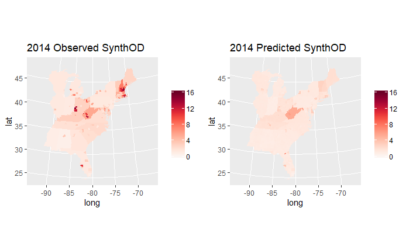

```r
results$county_fips <- results$county_code

counties <- urbnmapr::counties
counties$county_fips <- as.numeric(counties$county_fips)

counties <- left_join(results, counties, by = "county_fips")

max <- ceiling(max(max(results$observed_2014, na.rm = T),max(results$predicted_2014, na.rm = T)))

lims <- c(0,max)

g1 <- counties %>%
  ggplot(aes(long, lat, group = group, fill = observed_2014)) +
  scale_fill_continuous_sequential("Reds", na.value = "#FFEEEE", limits = c(0,16)) +
  geom_polygon() +
  coord_map(projection = "albers", lat0 = 39, lat1 = 45) +
  labs(fill = "") +
  theme(legend.title = element_text(colour="black", size=4,
                                      face="bold")) +
  ggtitle("2014 Observed SynthOD")

g2 <- counties %>%
  ggplot(aes(long, lat, group = group, fill = predicted_2014)) +
  scale_fill_continuous_sequential("Reds", na.value = "#FFEEEE", limits = c(0,16)) +
  geom_polygon() +
  coord_map(projection = "albers", lat0 = 39, lat1 = 45) +
  labs(fill = "") +
  theme(legend.title = element_text(colour="black", size=4,
                                      face="bold")) +
  ggtitle("2014 Predicted SynthOD")

grid.arrange(g1,g2,nrow=1)
```

```r
NA
NA
```

#### 2015

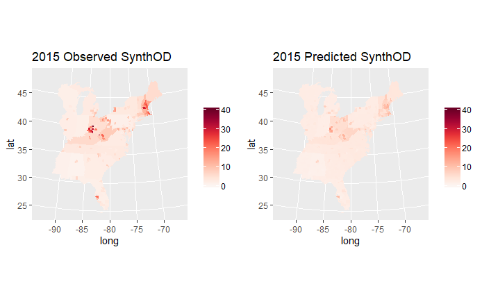

```r
max <- ceiling(max(max(results$observed_2015, na.rm = T),max(results$predicted_2015, na.rm = T)))


g1 <- counties %>%
  ggplot(aes(long, lat, group = group, fill = observed_2015)) +
  scale_fill_continuous_sequential("Reds", na.value = "#FFEEEE", limits = c(0,40)) +
  geom_polygon() +
  coord_map(projection = "albers", lat0 = 39, lat1 = 45) +
  labs(fill = "") +
  theme(legend.title = element_text(colour="black", size=4,
                                      face="bold")) +
  ggtitle("2015 Observed SynthOD")

g2 <- counties %>%
  ggplot(aes(long, lat, group = group, fill = predicted_2015)) +
  scale_fill_continuous_sequential("Reds", na.value = "#FFEEEE", limits = c(0,40)) +
  geom_polygon() +
  coord_map(projection = "albers", lat0 = 39, lat1 = 45) +
  labs(fill = "") +
  theme(legend.title = element_text(colour="black", size=4,
                                      face="bold")) +
  ggtitle("2015 Predicted SynthOD")

grid.arrange(g1,g2,nrow=1)
```

```r
NA
NA
```

#### 2016

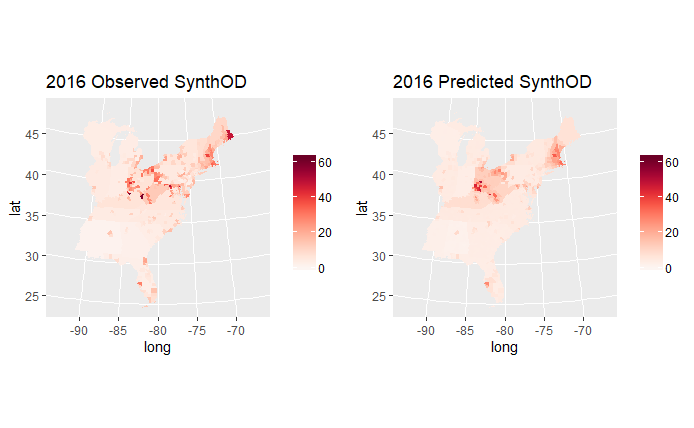

```r
max <- ceiling(max(max(results$observed_2016, na.rm = T),max(results$predicted_2016, na.rm = T)))


g1 <- counties %>%
  ggplot(aes(long, lat, group = group, fill = observed_2016)) +
  scale_fill_continuous_sequential("Reds", na.value = "#FFEEEE", limits = c(0,62)) +
  geom_polygon() +
  coord_map(projection = "albers", lat0 = 39, lat1 = 45) +
  labs(fill = "") +
  theme(legend.title = element_text(colour="black", size=4,
                                      face="bold")) +
  ggtitle("2016 Observed SynthOD")

g2 <- counties %>%
  ggplot(aes(long, lat, group = group, fill = predicted_2016)) +
  scale_fill_continuous_sequential("Reds", na.value = "#FFEEEE", limits = c(0,62)) +
  geom_polygon() +
  coord_map(projection = "albers", lat0 = 39, lat1 = 45) +
  labs(fill = "") +
  theme(legend.title = element_text(colour="black", size=4,
                                      face="bold")) +
  ggtitle("2016 Predicted SynthOD")

grid.arrange(g1,g2,nrow=1)
```

```r
NA
NA
```

#### 2017

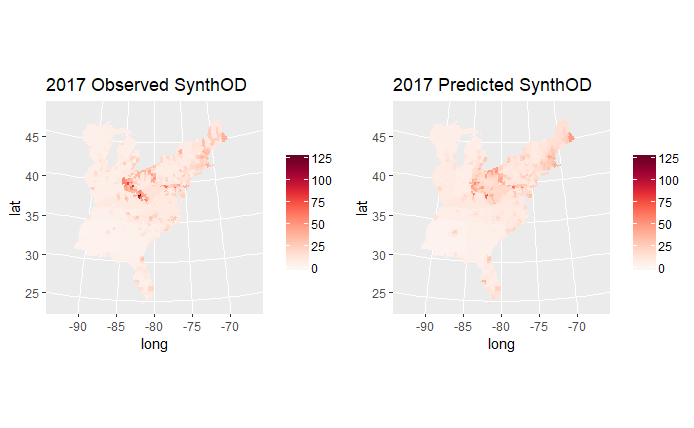

```r
max <- ceiling(max(max(results$observed_2017, na.rm = T),max(results$predicted_2017, na.rm = T)))


g1 <- counties %>%
  ggplot(aes(long, lat, group = group, fill = observed_2017)) +
  scale_fill_continuous_sequential("Reds", na.value = "#FFEEEE", limits = c(0,125)) +
  geom_polygon() +
  coord_map(projection = "albers", lat0 = 39, lat1 = 45) +
  labs(fill = "") +
  theme(legend.title = element_text(colour="black", size=4,
                                      face="bold")) +
  ggtitle("2017 Observed SynthOD")

g2 <- counties %>%
  ggplot(aes(long, lat, group = group, fill = predicted_2017)) +
  scale_fill_continuous_sequential("Reds", na.value = "#FFEEEE", limits = c(0,125)) +
  geom_polygon() +
  coord_map(projection = "albers", lat0 = 39, lat1 = 45) +
  labs(fill = "") +
  theme(legend.title = element_text(colour="black", size=4,
                                      face="bold")) +
  ggtitle("2017 Predicted SynthOD")

grid.arrange(g1,g2,nrow=1)
```

```r
NA
NA
```

#### 2018

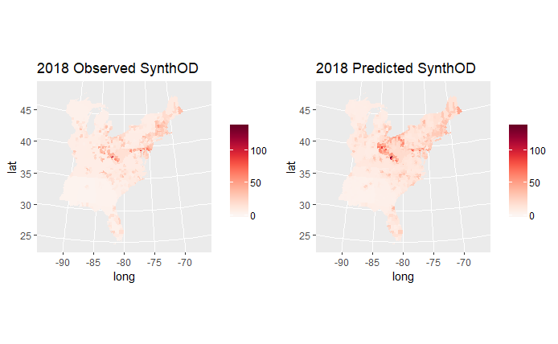

```r
max <- ceiling(max(max(results$observed_2018, na.rm = T),max(results$predicted_2018, na.rm = T)))


g1 <- counties %>%
  ggplot(aes(long, lat, group = group, fill = observed_2018)) +
  scale_fill_continuous_sequential("Reds", na.value = "#FFEEEE", limits = c(0,136)) +
  geom_polygon() +
  coord_map(projection = "albers", lat0 = 39, lat1 = 45) +
  labs(fill = "") +
  theme(legend.title = element_text(colour="black", size=4,
                                      face="bold")) +
  ggtitle("2018 Observed SynthOD")

g2 <- counties %>%
  ggplot(aes(long, lat, group = group, fill = predicted_2018)) +
  scale_fill_continuous_sequential("Reds", na.value = "#FFEEEE", limits = c(0,136)) +
  geom_polygon() +
  coord_map(projection = "albers", lat0 = 39, lat1 = 45) +
  labs(fill = "") +
  theme(legend.title = element_text(colour="black", size=4,
                                      face="bold")) +
  ggtitle("2018 Predicted SynthOD")

grid.arrange(g1,g2,nrow=1)
```

```r
NA
NA
```

### Year By Year Rank Order Maps

```r
results$observed_2014_rank[order(-results$observed_2014)] <- 1:nrow(results)
results$observed_2015_rank[order(-results$observed_2015)] <- 1:nrow(results)
results$observed_2016_rank[order(-results$observed_2016)] <- 1:nrow(results)
results$observed_2017_rank[order(-results$observed_2017)] <- 1:nrow(results)
results$observed_2018_rank[order(-results$observed_2018)] <- 1:nrow(results)

results$predicted_2014_rank[order(-results$predicted_2014)] <- 1:nrow(results)
results$predicted_2015_rank[order(-results$predicted_2015)] <- 1:nrow(results)
results$predicted_2016_rank[order(-results$predicted_2016)] <- 1:nrow(results)
results$predicted_2017_rank[order(-results$predicted_2017)] <- 1:nrow(results)
results$predicted_2018_rank[order(-results$predicted_2018)] <- 1:nrow(results)

results$observed_2014_percentile <- NA
results$observed_2015_percentile <- NA
results$observed_2016_percentile <- NA
results$observed_2017_percentile <- NA
results$observed_2018_percentile <- NA

results$predicted_2014_percentile <- NA
results$predicted_2015_percentile <- NA
results$predicted_2016_percentile <- NA
results$predicted_2017_percentile <- NA
results$predicted_2018_percentile <- NA

percentile_size <- floor(nrow(results)/10)

for(i in 1:10){

  threshold_lower <- (i-1)*percentile_size
  threshold_upper <- (i)*percentile_size

  results$observed_2014_percentile[results$observed_2014_rank > threshold_lower & results$observed_2014_rank <= threshold_upper] <- i
  results$observed_2015_percentile[results$observed_2015_rank > threshold_lower & results$observed_2015_rank <= threshold_upper] <- i
  results$observed_2016_percentile[results$observed_2016_rank > threshold_lower & results$observed_2016_rank <= threshold_upper] <- i
  results$observed_2017_percentile[results$observed_2017_rank > threshold_lower & results$observed_2017_rank <= threshold_upper] <- i
  results$observed_2018_percentile[results$observed_2018_rank > threshold_lower & results$observed_2018_rank <= threshold_upper] <- i

  results$predicted_2014_percentile[results$predicted_2014_rank > threshold_lower & results$predicted_2014_rank <= threshold_upper] <- i
  results$predicted_2015_percentile[results$predicted_2015_rank > threshold_lower & results$predicted_2015_rank <= threshold_upper] <- i
  results$predicted_2016_percentile[results$predicted_2016_rank > threshold_lower & results$predicted_2016_rank <= threshold_upper] <- i
  results$predicted_2017_percentile[results$predicted_2017_rank > threshold_lower & results$predicted_2017_rank <= threshold_upper] <- i
  results$predicted_2018_percentile[results$predicted_2018_rank > threshold_lower & results$predicted_2018_rank <= threshold_upper] <- i

}
```

#### 2014

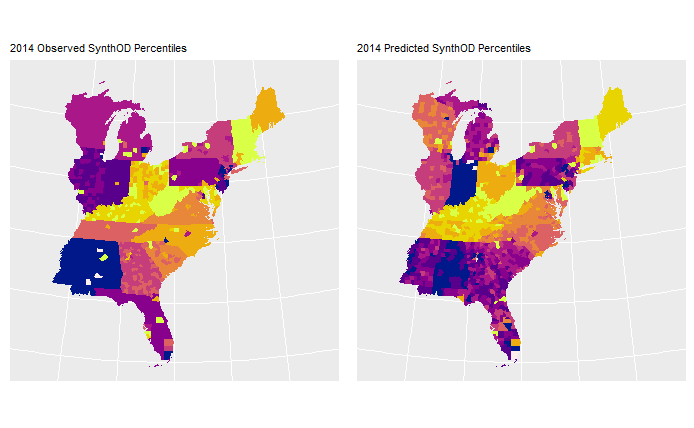

```r
results$county_fips <- results$county_code

counties <- urbnmapr::counties
counties$county_fips <- as.numeric(counties$county_fips)

counties <- left_join(results, counties, by = "county_fips")

g1 <- counties %>%
  ggplot(aes(long, lat, group = group, fill = observed_2014_percentile)) +
  scale_fill_continuous_sequential("Plasma", na.value = "#FFEEEE") +
  geom_polygon() +
  coord_map(projection = "albers", lat0 = 39, lat1 = 45) +
  labs(fill = "2017 Observed Percentiles") +
  theme(legend.position = "none", axis.title = element_blank(), axis.ticks = element_blank(), axis.text = element_blank(),plot.title = element_text(size = 8)) +
  ggtitle("2014 Observed SynthOD Percentiles")

g2 <- counties %>%
  ggplot(aes(long, lat, group = group, fill = predicted_2014_percentile)) +
  scale_fill_continuous_sequential("Plasma", na.value = "#FFEEEE") +
  geom_polygon() +
  coord_map(projection = "albers", lat0 = 39, lat1 = 45) +
  labs(fill = "2017 Observed Percentiles") +
  theme(legend.position = "none", axis.title = element_blank(), axis.ticks = element_blank(), axis.text = element_blank(),plot.title = element_text(size = 8)) +
  ggtitle("2014 Predicted SynthOD Percentiles")

grid.arrange(g1,g2,nrow=1)
```

#### 2015

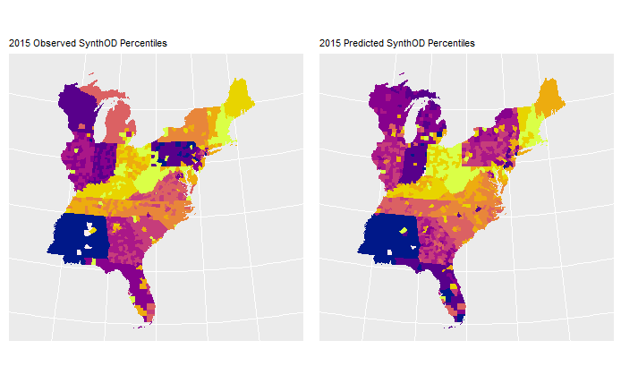

```r
results$county_fips <- results$county_code

counties <- urbnmapr::counties
counties$county_fips <- as.numeric(counties$county_fips)

counties <- left_join(results, counties, by = "county_fips")

g1 <- counties %>%
  ggplot(aes(long, lat, group = group, fill = observed_2015_percentile)) +
  scale_fill_continuous_sequential("Plasma", na.value = "#FFEEEE") +
  geom_polygon() +
  coord_map(projection = "albers", lat0 = 39, lat1 = 45) +
  labs(fill = "2017 Observed Percentiles") +
  theme(legend.position = "none", axis.title = element_blank(), axis.ticks = element_blank(), axis.text = element_blank(),plot.title = element_text(size = 8)) +
  ggtitle("2015 Observed SynthOD Percentiles")

g2 <- counties %>%
  ggplot(aes(long, lat, group = group, fill = predicted_2015_percentile)) +
  scale_fill_continuous_sequential("Plasma", na.value = "#FFEEEE") +
  geom_polygon() +
  coord_map(projection = "albers", lat0 = 39, lat1 = 45) +
  labs(fill = "2017 Observed Percentiles") +
  theme(legend.position = "none", axis.title = element_blank(), axis.ticks = element_blank(), axis.text = element_blank(),plot.title = element_text(size = 8)) +
  ggtitle("2015 Predicted SynthOD Percentiles")

grid.arrange(g1,g2,nrow=1)
```

#### 2016

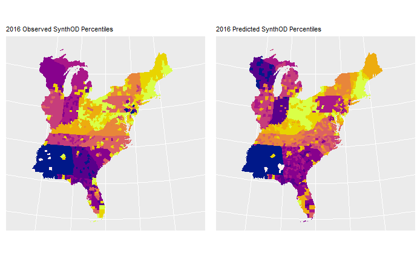

```r
results$county_fips <- results$county_code

counties <- urbnmapr::counties
counties$county_fips <- as.numeric(counties$county_fips)

counties <- left_join(results, counties, by = "county_fips")

g1 <- counties %>%
  ggplot(aes(long, lat, group = group, fill = observed_2016_percentile)) +
  scale_fill_continuous_sequential("Plasma", na.value = "#FFEEEE") +
  geom_polygon() +
  coord_map(projection = "albers", lat0 = 39, lat1 = 45) +
  labs(fill = "2017 Observed Percentiles") +
  theme(legend.position = "none", axis.title = element_blank(), axis.ticks = element_blank(), axis.text = element_blank(),plot.title = element_text(size = 8)) +
  ggtitle("2016 Observed SynthOD Percentiles")

g2 <- counties %>%
  ggplot(aes(long, lat, group = group, fill = predicted_2016_percentile)) +
  scale_fill_continuous_sequential("Plasma", na.value = "#FFEEEE") +
  geom_polygon() +
  coord_map(projection = "albers", lat0 = 39, lat1 = 45) +
  labs(fill = "2017 Observed Percentiles") +
  theme(legend.position = "none", axis.title = element_blank(), axis.ticks = element_blank(), axis.text = element_blank(),plot.title = element_text(size = 8)) +
  ggtitle("2016 Predicted SynthOD Percentiles")

grid.arrange(g1,g2,nrow=1)
```

#### 2017

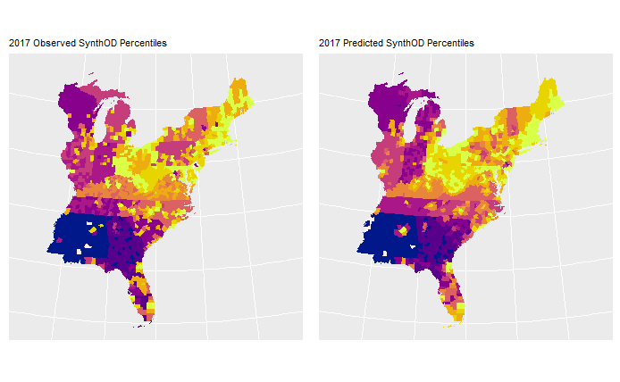

```r
results$county_fips <- results$county_code

counties <- urbnmapr::counties
counties$county_fips <- as.numeric(counties$county_fips)

counties <- left_join(results, counties, by = "county_fips")

g1 <- counties %>%
  ggplot(aes(long, lat, group = group, fill = observed_2017_percentile)) +
  scale_fill_continuous_sequential("Plasma", na.value = "#FFEEEE") +
  geom_polygon() +
  coord_map(projection = "albers", lat0 = 39, lat1 = 45) +
  labs(fill = "2017 Observed Percentiles") +
  theme(legend.position = "none", axis.title = element_blank(), axis.ticks = element_blank(), axis.text = element_blank(),plot.title = element_text(size = 8)) +
  ggtitle("2017 Observed SynthOD Percentiles")

g2 <- counties %>%
  ggplot(aes(long, lat, group = group, fill = predicted_2017_percentile)) +
  scale_fill_continuous_sequential("Plasma", na.value = "#FFEEEE") +
  geom_polygon() +
  coord_map(projection = "albers", lat0 = 39, lat1 = 45) +
  labs(fill = "2017 Observed Percentiles") +
  theme(legend.position = "none", axis.title = element_blank(), axis.ticks = element_blank(), axis.text = element_blank(),plot.title = element_text(size = 8)) +
  ggtitle("2017 Predicted SynthOD Percentiles")

grid.arrange(g1,g2,nrow=1)
```

#### 2018

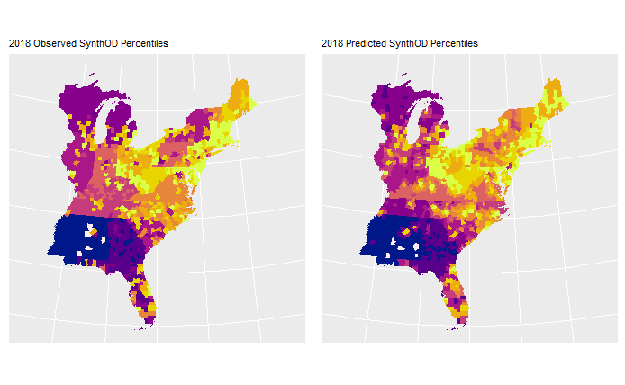

```r
results$county_fips <- results$county_code

counties <- urbnmapr::counties
counties$county_fips <- as.numeric(counties$county_fips)

counties <- left_join(results, counties, by = "county_fips")

g1 <- counties %>%
  ggplot(aes(long, lat, group = group, fill = observed_2018_percentile)) +
  scale_fill_continuous_sequential("Plasma", na.value = "#FFEEEE") +
  geom_polygon() +
  coord_map(projection = "albers", lat0 = 39, lat1 = 45) +
  labs(fill = "2017 Observed Percentiles") +
  theme(legend.position = "none", axis.title = element_blank(), axis.ticks = element_blank(), axis.text = element_blank(),plot.title = element_text(size = 8)) +
  ggtitle("2018 Observed SynthOD Percentiles")

g2 <- counties %>%
  ggplot(aes(long, lat, group = group, fill = predicted_2018_percentile)) +
  scale_fill_continuous_sequential("Plasma", na.value = "#FFEEEE") +
  geom_polygon() +
  coord_map(projection = "albers", lat0 = 39, lat1 = 45) +
  labs(fill = "2017 Observed Percentiles") +
  theme(legend.position = "none", axis.title = element_blank(), axis.ticks = element_blank(), axis.text = element_blank(),plot.title = element_text(size = 8)) +
  ggtitle("2018 Predicted SynthOD Percentiles")

grid.arrange(g1,g2,nrow=1)
```

### Percentile Tables

In the following tables it displays how the observed percentiles overlapped with the predicted percentiles. The rows are the observed and the columns are the predicted.

#### 2014

```r
table(results$observed_2014_percentile, results$predicted_2014_percentile)
```

```
       1   2   3   4   5   6   7   8   9  10
  1  110  25  14   2   5   1   0   1   2   0
  2   38  61  39  12   9   0   1   0   0   0
  3    5  17  40  38  57   0   0   1   1   1
  4    1   0  18  79  26   5  22   6   2   1
  5    2  56  38   2   1   8  14  19  18   1
  6    2   0   1   1   4  42  41  31  30   8
  7    1   0   4  25  45  11  44  26   2   2
  8    1   0   1   1   3  44  21  45  39   5
  9    0   1   3   0  10  43   5   2   5  88
  10   0   0   2   0   0   6  12  28  60  51
```

#### 2015

```r
table(results$observed_2015_percentile, results$predicted_2015_percentile)
```

```
       1   2   3   4   5   6   7   8   9  10
  1  113  23   9   4   4   4   1   0   1   0
  2   18  94  45   1   0   0   2   0   0   0
  3   26  38  26   3  61   3   0   3   0   0
  4    1   0   8  66  37  11  25  12   0   0
  5    2   1  37  43   4   2   2  45  23   1
  6    0   2  26  38  40  25  16  11   2   0
  7    0   0   1   0   9  70  64  15   0   1
  8    0   1   4   2   4  19  19  10  91  10
  9    0   1   4   3   1  19  24  63  42   0
  10   0   0   0   0   0   7   7   1   1 143
```

#### 2016

```r
table(results$observed_2016_percentile, results$predicted_2016_percentile)
```

```
       1   2   3   4   5   6   7   8   9  10
  1   90  36  22   2   3   0   3   2   2   0
  2   27  37  61   8   6   8   8   4   0   1
  3   40  70  46   1   0   0   1   0   1   1
  4    1   9   8  63  72   4   1   2   0   0
  5    1   5   6   8  55  38  42   5   0   0
  6    0   0   4  58  12  61  23   1   1   0
  7    1   1   6  16  10  45  20   1  59   1
  8    0   1   6   3   2   4   3  42  83  16
  9    0   1   0   1   0   0  50  94  14   0
  10   0   0   1   0   0   0   9   9   0 135
```

#### 2017

```r
table(results$observed_2017_percentile, results$predicted_2017_percentile)
```

```
       1   2   3   4   5   6   7   8   9  10
  1  106  33  10   3   6   2   0   0   0   0
  2   41  62  23  12   8   8   2   2   1   1
  3    8  56  41  12  27   5   2   9   0   0
  4    3   0  31  59  66   1   0   0   0   0
  5    1   5  37  41  16  54   5   0   1   0
  6    1   2  15  18  16  47  26  34   1   0
  7    0   0   0   9   7  33  82  27   0   2
  8    0   1   3   6   9   6  37  78  19   1
  9    0   1   0   0   5   2   1   9 121  21
  10   0   0   0   0   0   0   5   1  16 132
```

#### 2018

```r
table(results$observed_2018_percentile, results$predicted_2018_percentile)
```

```
       1   2   3   4   5   6   7   8   9  10
  1  108  29   6   9   1   3   4   0   0   0
  2   30  80  24   8   4   7   3   4   0   0
  3   16  32  64  23   2  17   4   2   0   0
  4    2   5  43  35  60  15   0   0   0   0
  5    2   6   7  31  35  39  36   4   0   0
  6    0   4   8  23  45  16   6  58   0   0
  7    2   3   6  28  11  36  66   7   1   0
  8    0   1   1   3   2  26  29  80  18   0
  9    0   0   0   0   0   1  12   2 114  31
  10   0   0   1   0   0   0   0   2  26 126
```

## Model Diagnostics

### Scatterplots

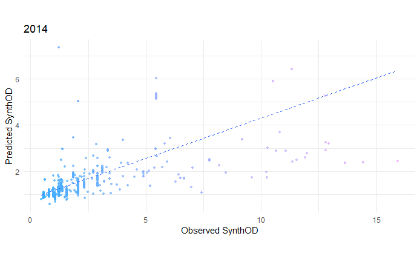

```r
results$pc <- predict(prcomp(~observed_2014+predicted_2014, results))[,1]
results$density <- fields::interp.surface(
  MASS::kde2d(results$observed_2014, results$predicted_2014), results[,c("observed_2014", "predicted_2014")])

ggplot(results, aes(x=observed_2014, y=predicted_2014,color = pc, alpha = 1/density)) + geom_point(shape = 16, size = 1, show.legend = FALSE) +
  theme_minimal() +
  scale_color_gradient(low = "#32aeff", high = "#f2aeff") +
  coord_fixed(ratio = 1) +
  scale_alpha(range = c(.75, 1)) +
  geom_smooth(method = "lm", show.legend = F, se=F, linetype="dashed", size = 0.5) +
  labs(y = "Predicted SynthOD",x="Observed SynthOD") +
  ggtitle("2014")
```

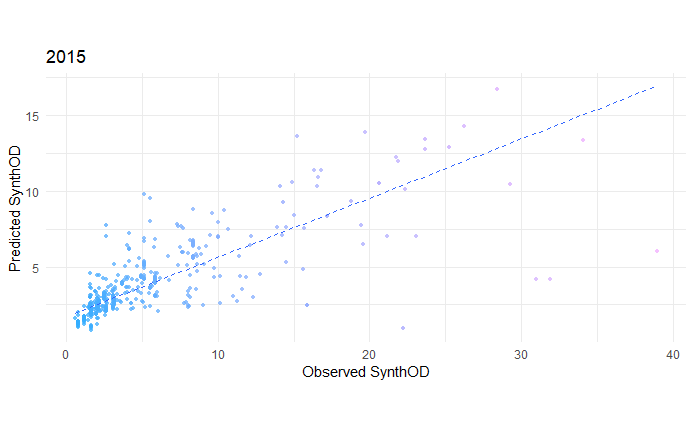

```r
results$pc <- predict(prcomp(~observed_2015+predicted_2015, results))[,1]
results$density <- fields::interp.surface(
  MASS::kde2d(results$observed_2015, results$predicted_2015), results[,c("observed_2015", "predicted_2015")])

 ggplot(results, aes(x=observed_2015, y=predicted_2015,color = pc, alpha = 1/density)) + geom_point(shape = 16, size = 1, show.legend = FALSE) +
  theme_minimal() +
  scale_color_gradient(low = "#32aeff", high = "#f2aeff") +
  coord_fixed(ratio = 1) +
  scale_alpha(range = c(.75, 1)) +
  geom_smooth(method = "lm", show.legend = F, se=F, linetype="dashed", size = 0.5) +
  labs(y = "Predicted SynthOD",x="Observed SynthOD") +
  ggtitle("2015")
```

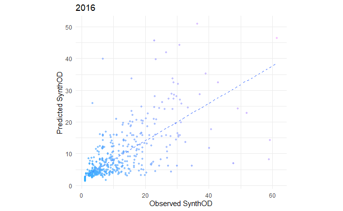

```r
 results$pc <- predict(prcomp(~observed_2016+predicted_2016, results))[,1]
results$density <- fields::interp.surface(
  MASS::kde2d(results$observed_2016, results$predicted_2016), results[,c("observed_2016", "predicted_2016")])

ggplot(results, aes(x=observed_2016, y=predicted_2016,color = pc, alpha = 1/density)) + geom_point(shape = 16, size = 1, show.legend = FALSE) +
  theme_minimal() +
  scale_color_gradient(low = "#32aeff", high = "#f2aeff") +
  coord_fixed(ratio = 1) +
  scale_alpha(range = c(.75, 1)) +
  geom_smooth(method = "lm", show.legend = F, se=F, linetype="dashed", size = 0.5) +
  labs(y = "Predicted SynthOD",x="Observed SynthOD") +
  ggtitle("2016")
```

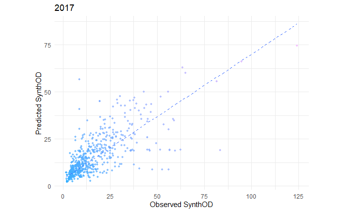

```r
results$pc <- predict(prcomp(~observed_2017+predicted_2017, results))[,1]
results$density <- fields::interp.surface(
  MASS::kde2d(results$observed_2017, results$predicted_2017), results[,c("observed_2017", "predicted_2017")])

ggplot(results, aes(x=observed_2017, y=predicted_2017,color = pc, alpha = 1/density)) + geom_point(shape = 16, size = 1, show.legend = FALSE) +
  theme_minimal() +
  scale_color_gradient(low = "#32aeff", high = "#f2aeff") +
  coord_fixed(ratio = 1) +
  scale_alpha(range = c(.75, 1)) +
  geom_smooth(method = "lm", show.legend = F, se=F, linetype="dashed", size = 0.5) +
  labs(y = "Predicted SynthOD",x="Observed SynthOD") +
  ggtitle("2017")
```

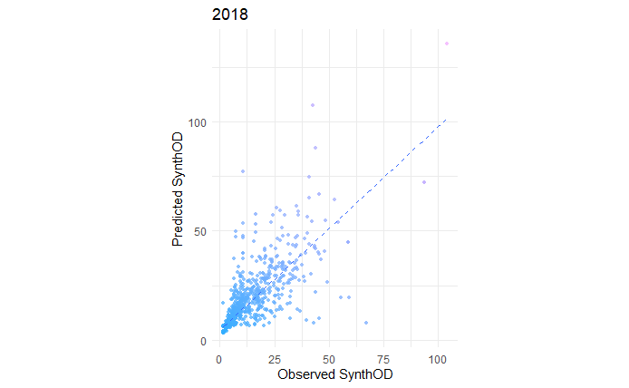

```r
results$pc <- predict(prcomp(~observed_2018+predicted_2018, results))[,1]
results$density <- fields::interp.surface(
  MASS::kde2d(results$observed_2018, results$predicted_2018), results[,c("observed_2018", "predicted_2018")])

ggplot(results, aes(x=observed_2018, y=predicted_2018,color = pc, alpha = 1/density)) + geom_point(shape = 16, size = 1, show.legend = FALSE) +
  theme_minimal() +
  scale_color_gradient(low = "#32aeff", high = "#f2aeff") +
  coord_fixed(ratio = 1) +
  scale_alpha(range = c(.75, 1)) +
  geom_smooth(method = "lm", show.legend = F, se=F, linetype="dashed", size = 0.5) +
  labs(y = "Predicted SynthOD",x="Observed SynthOD") +
  ggtitle("2018")
```

```r
NA
NA
NA
```

### BarPlots

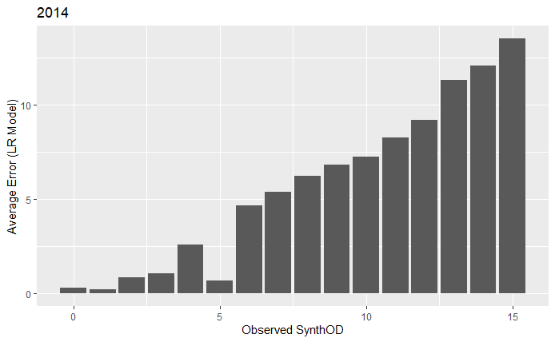

```r
results$error_2014 <- abs(results$observed_2014 - results$predicted_2014)
results$observed_floor_2014 <- floor(results$observed_2014)

ggplot(results, aes(x =observed_floor_2014,y=error_2014)) +
         geom_bar( position = "dodge", stat = "summary", fun.y = "mean") +
  labs(x = "Observed SynthOD", y="Average Error (LR Model)") +
  ggtitle("2014")
```

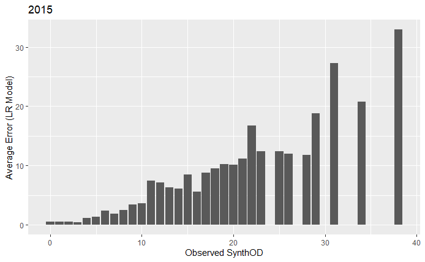

```r
results$error_2015 <- abs(results$observed_2015 - results$predicted_2015)
results$observed_floor_2015 <- floor(results$observed_2015)

ggplot(results, aes(x =observed_floor_2015,y=error_2015)) +
         geom_bar( position = "dodge", stat = "summary", fun.y = "mean") +
  labs(x = "Observed SynthOD", y="Average Error (LR Model)") +
  ggtitle("2015")
```

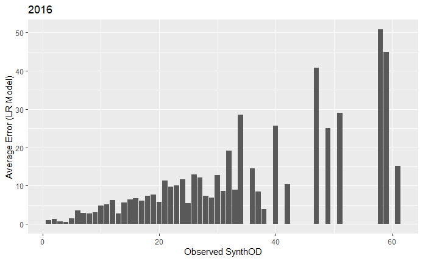

```r
results$error_2016 <- abs(results$observed_2016 - results$predicted_2016)
results$observed_floor_2016 <- floor(results$observed_2016)

ggplot(results, aes(x =observed_floor_2016,y=error_2016)) +
         geom_bar( position = "dodge", stat = "summary", fun.y = "mean") +
  labs(x = "Observed SynthOD", y="Average Error (LR Model)") +
  ggtitle("2016")
```

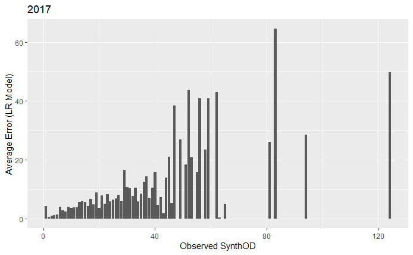

```r
results$error_2017 <- abs(results$observed_2017 - results$predicted_2017)
results$observed_floor_2017 <- floor(results$observed_2017)

ggplot(results, aes(x =observed_floor_2017,y=error_2017)) +
         geom_bar( position = "dodge", stat = "summary", fun.y = "mean") +
  labs(x = "Observed SynthOD", y="Average Error (LR Model)") +
  ggtitle("2017")
```

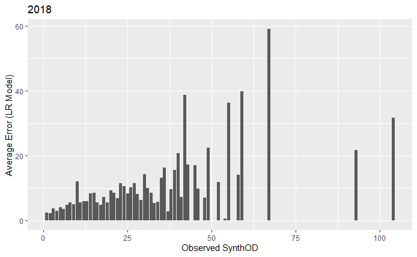

```r
results$error_2018 <- abs(results$observed_2018 - results$predicted_2018)
results$observed_floor_2018 <- floor(results$observed_2018)

ggplot(results, aes(x =observed_floor_2018,y=error_2018)) +
         geom_bar( position = "dodge", stat = "summary", fun.y = "mean") +
  labs(x = "Observed SynthOD", y="Average Error (LR Model)") +
  ggtitle("2018")
```

```r
NA
NA
NA
NA
NA
NA
```

## Predicting 2018 on the Western US

Now we will apply our model trained up to 2017 to try to predict 2018 rates on the west half of the country. We saved this model earlier as “lr_model_save”

```r
## test data is west of mississippi
`%!in%` = Negate(`%in%`)


#subset the test data
test_data <- data[data$year == 2017,]
test_data <- test_data[as.numeric(as.character(test_data$state)) %!in% east_miss,]

results <- test_data[,2:3]

results$observed_2018 <- test_data$next_year_synthetic_opioid_death_rate
results$predicted_2018 <- predict(lr_model, test_data)
```

### Top 10% Of Counties

```r
results$observed_2018_rank[order(-results$observed_2018)] <- 1:nrow(results)


results$predicted_2018_rank[order(-results$predicted_2018)] <- 1:nrow(results)


results$observed_2018_percentile <- NA

results$predicted_2018_percentile <- NA

percentile_size <- floor(nrow(results)/10)

for(i in 1:10){

  threshold_lower <- (i-1)*percentile_size
  threshold_upper <- (i)*percentile_size

  results$observed_2018_percentile[results$observed_2018_rank > threshold_lower & results$observed_2018_rank <= threshold_upper] <- i

  results$predicted_2018_percentile[results$predicted_2018_rank > threshold_lower & results$predicted_2018_rank <= threshold_upper] <- i

}

results$observed_2018_percentile[results$observed_2018_percentile > 1] <- 2
results$predicted_2018_percentile[results$predicted_2018_percentile > 1] <- 2
```

#### Map

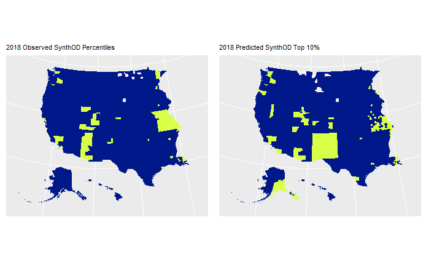

```r
results$county_fips <- results$county_code

counties <- urbnmapr::counties
counties$county_fips <- as.numeric(counties$county_fips)

counties <- left_join(results, counties, by = "county_fips")

g1 <- counties %>%
  ggplot(aes(long, lat, group = group, fill = observed_2018_percentile)) +
  scale_fill_continuous_sequential("Plasma", na.value = "#FFEEEE") +
  geom_polygon() +
  coord_map(projection = "albers", lat0 = 39, lat1 = 45) +
  labs(fill = "2017 Observed Percentiles") +
  theme(legend.position = "none", axis.title = element_blank(), axis.ticks = element_blank(), axis.text = element_blank(),plot.title = element_text(size = 8)) +
  ggtitle("2018 Observed SynthOD Percentiles")

g2 <- counties %>%
  ggplot(aes(long, lat, group = group, fill = predicted_2018_percentile)) +
  scale_fill_continuous_sequential("Plasma", na.value = "#FFEEEE") +
  geom_polygon() +
  coord_map(projection = "albers", lat0 = 39, lat1 = 45) +
  labs(fill = "2017 Observed Top 10%") +
  theme(legend.position = "none", axis.title = element_blank(), axis.ticks = element_blank(), axis.text = element_blank(),plot.title = element_text(size = 8)) +
  ggtitle("2018 Predicted SynthOD Top 10%")

grid.arrange(g1,g2,nrow=1)
```

```r
NA
NA
```